# Exercise Type Prediction

## author: Evan Althouse

Course Project for Coursera’s Practical Machine Learning course

## Executive Summary

We use training data from 6 participants, using exercise tracking devices, in order to predict the type of activity done based on several quantitative features. We train a model using a large amount of past data, and using cross validation, estimate the errors on a larger testing set. We then use the model to predict 20 test cases.

## Data Import and Cleaning

We begin by first loading the data and the necessary libraries.

```r
library(randomForest)
library(caret)
library(ggplot2)

if (!file.exists("pml-training.csv")) {
    url <- "https://d396qusza40orc.cloudfront.net/predmachlearn/pml-training.csv"
    download.file(url, destfile = "pml-training.csv")
}
raw.training.data <- read.csv("pml-training.csv")

if (!file.exists("pml-testing.csv")) {
    url <- "https://d396qusza40orc.cloudfront.net/predmachlearn/pml-testing.csv"
    download.file(url, destfile = "pml-testing.csv")
}
raw.testing.data <- read.csv("pml-testing.csv")

set.seed(4444)
```

From looking at the files in Excel, we know that there are many NA values in both the training and testing set. On top of this, the first 6 columns are strictly explanatory, and give us identifying information on the data row (date, time, etc.). We exclude variables that have no use to us, based on the values in the testing set.

```r
out.of.testing <- numeric()

for (ii in 1:ncol(raw.training.data)) {
    if (sum(is.na(raw.testing.data[,ii])) == 20) {
        out.of.testing <- c(out.of.testing, ii)
    }
}

training.data <- raw.training.data[,-out.of.testing]
testing.data <- raw.testing.data[,-out.of.testing]

training.data <- training.data[, 6:ncol(training.data)]
testing.data <- testing.data[, 6:ncol(testing.data)]
```

We still have a relatively large feature space, so we aim to reduce the dimensionality of it with PCA. We use the prcomp() function to compute the principal components, and look at the results.

```r
pc <- prcomp(training.data[,2:(ncol(training.data)-1)])

summary(pc)
```

```
## Importance of components:
##                             PC1      PC2      PC3      PC4      PC5
## Standard deviation     599.4420 534.2659 476.4931 380.3042 357.4983
## Proportion of Variance   0.2522   0.2003   0.1593   0.1015   0.0897
## Cumulative Proportion    0.2522   0.4525   0.6119   0.7134   0.8031
##                              PC6       PC7       PC8       PC9      PC10
## Standard deviation     254.94714 235.15398 198.26708 173.30458 158.01845
## Proportion of Variance   0.04562   0.03881   0.02759   0.02108   0.01752
## Cumulative Proportion    0.84871   0.88752   0.91511   0.93619   0.95371
##                             PC11     PC12     PC13     PC14     PC15
## Standard deviation     117.91466 96.00259 89.49378 76.28439 68.43728
## Proportion of Variance   0.00976  0.00647  0.00562  0.00408  0.00329
## Cumulative Proportion    0.96347  0.96994  0.97556  0.97965  0.98293
##                            PC16     PC17     PC18     PC19     PC20
## Standard deviation     62.42238 56.59833 53.23786 49.69283 48.63873
## Proportion of Variance  0.00273  0.00225  0.00199  0.00173  0.00166
## Cumulative Proportion   0.98567  0.98792  0.98991  0.99164  0.99330
##                            PC21     PC22     PC23     PC24     PC25
## Standard deviation     41.82223 37.47787 35.11193 32.88038 30.67723
## Proportion of Variance  0.00123  0.00099  0.00087  0.00076  0.00066
## Cumulative Proportion   0.99453  0.99551  0.99638  0.99714  0.99780
##                            PC26     PC27     PC28     PC29     PC30
## Standard deviation     25.50470 23.25093 21.52949 20.33647 17.12486
## Proportion of Variance  0.00046  0.00038  0.00033  0.00029  0.00021
## Cumulative Proportion   0.99825  0.99863  0.99896  0.99925  0.99945
##                            PC31     PC32    PC33    PC34    PC35    PC36
## Standard deviation     15.13038 13.98251 9.87542 7.61828 7.29081 6.67484
## Proportion of Variance  0.00016  0.00014 0.00007 0.00004 0.00004 0.00003
## Cumulative Proportion   0.99961  0.99975 0.99982 0.99986 0.99990 0.99993
##                           PC37    PC38    PC39    PC40    PC41  PC42  PC43
## Standard deviation     6.12838 4.12083 3.75684 3.49805 3.35869 1.957 1.492
## Proportion of Variance 0.00003 0.00001 0.00001 0.00001 0.00001 0.000 0.000
## Cumulative Proportion  0.99996 0.99997 0.99998 0.99999 0.99999 1.000 1.000
##                         PC44  PC45   PC46   PC47   PC48  PC49   PC50  PC51
## Standard deviation     1.097 0.465 0.3937 0.3601 0.3148 0.241 0.2024 0.186
## Proportion of Variance 0.000 0.000 0.0000 0.0000 0.0000 0.000 0.0000 0.000
## Cumulative Proportion  1.000 1.000 1.0000 1.0000 1.0000 1.000 1.0000 1.000
##                          PC52   PC53
## Standard deviation     0.1041 0.0368
## Proportion of Variance 0.0000 0.0000
## Cumulative Proportion  1.0000 1.0000
```

We see that the first 19 components explain over 99% of the variance, so we use those as our predictors. This also requires us to translate the testing set into this new feature space. We create our final training and testing sets now.

```r
pcs <- as.data.frame(pc$x[,1:19])
pcs <- cbind(pcs, classe=raw.training.data$classe)

pca.testing.data <- predict(pc, testing.data[, 2:(ncol(testing.data)-1)])
pcs.testing <- pca.testing.data[,1:19]
```

In order to prepare for training a model, we first create two folds in the data in order to do simple 2-fold cross validation.

```r
folds <- createDataPartition(y=pcs$classe, p=0.5, list=FALSE)

firstFold <- pcs[folds,]
secondFold <- pcs[-folds,]
```

We then perform the cross validation, training a model on the first fold, then the second fold, and testing on the opposite fold.

**Side note** - We chose a random forest model due to its performance and its intuitive nature. One of the lecture videos mentioned it being a more complex model that is difficult to interpret, but I disagree. A decision tree is one of the most intuitive models available, and a random forest is simply a collection of decision trees.

```r
rf1 <- randomForest(classe ~., data=firstFold, type="classification", ntree=100,
                    nodesize=1, xtest=secondFold[,1:19], ytest=secondFold[,20])

rf1
```

```
##
## Call:
##  randomForest(formula = classe ~ ., data = firstFold, type = "classification",      ntree = 100, nodesize = 1, xtest = secondFold[, 1:19], ytest = secondFold[,          20])
##                Type of random forest: classification
##                      Number of trees: 100
## No. of variables tried at each split: 4
##
##         OOB estimate of  error rate: 3.68%
## Confusion matrix:
##      A    B    C    D    E class.error
## A 2755   14    6   14    1  0.01254480
## B   42 1804   40    8    5  0.05002633
## C    6   40 1645   15    5  0.03857393
## D    6    4   77 1505   16  0.06405473
## E    3   21    8   30 1742  0.03436807
##                 Test set error rate: 3.65%
## Confusion matrix:
##      A    B    C    D    E class.error
## A 2767   10    3    7    3 0.008243728
## B   41 1790   48   15    4 0.056902002
## C    1   40 1652   15    3 0.034482759
## D    8    9   66 1509   16 0.061567164
## E    3   21    9   36 1734 0.038269551
```

```r
rf2 <- randomForest(classe ~., data=secondFold, type="classification", ntree=100,
                    nodesize=1, xtest=firstFold[,1:19], ytest=firstFold[,20])

rf2
```

```
##
## Call:
##  randomForest(formula = classe ~ ., data = secondFold, type = "classification",      ntree = 100, nodesize = 1, xtest = firstFold[, 1:19], ytest = firstFold[,          20])
##                Type of random forest: classification
##                      Number of trees: 100
## No. of variables tried at each split: 4
##
##         OOB estimate of  error rate: 3.86%
## Confusion matrix:
##      A    B    C    D    E class.error
## A 2758   13    6    9    4  0.01146953
## B   46 1800   29    9   14  0.05163330
## C    6   42 1639   23    1  0.04208065
## D    8   10   77 1490   23  0.07338308
## E    5   18   13   23 1744  0.03272324
##                 Test set error rate: 3.26%
## Confusion matrix:
##      A    B    C    D    E class.error
## A 2758   14    5    9    4  0.01146953
## B   41 1815   29    6    8  0.04423381
## C   11   35 1651    9    5  0.03506721
## D    3    2   73 1519   11  0.05534826
## E    3   12   11   29 1749  0.03048780
```

We see that the test set error rates are hovering around 3%, which is acceptable for our model. We move onto the final model, utilizing the entire training set.

```r
rf <- randomForest(classe ~., data=pcs, type="classification", ntree=100, nodesize=1)

rf
```

```
##
## Call:
##  randomForest(formula = classe ~ ., data = pcs, type = "classification",      ntree = 100, nodesize = 1)
##                Type of random forest: classification
##                      Number of trees: 100
## No. of variables tried at each split: 4
##
##         OOB estimate of  error rate: 1.72%
## Confusion matrix:
##      A    B    C    D    E class.error
## A 5555    7   10    6    2 0.004480287
## B   39 3708   32    6   12 0.023439558
## C    5   35 3361   17    4 0.017825833
## D    2    5   92 3103   14 0.035136816
## E    0   12    9   28 3558 0.013584696
```

We again affirm that the estimate of the error rate is very small at less than 2%.

We look at a plot of the error rate to see if there are any parameters that need changing (mainly ntrees).

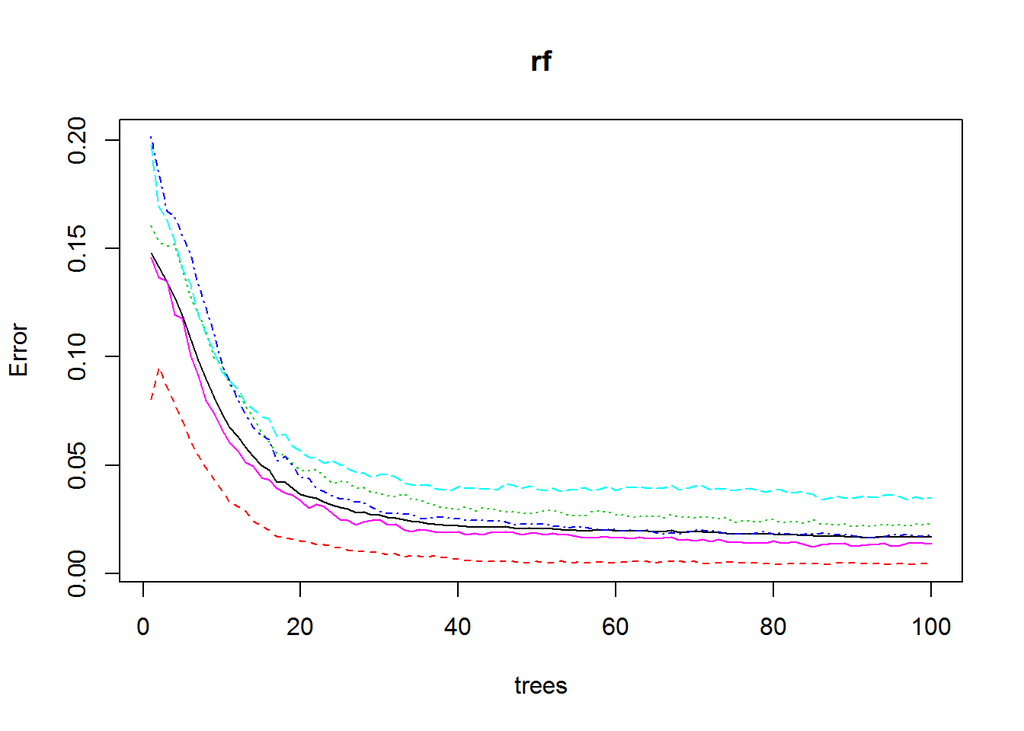

```r
plot(rf)
```

We then conclude our analysis by predicting our test cases, and readying them for submission.

```r
prediction <- predict(rf, pcs.testing)

pml_write_files = function(x){
  n = length(x)
  for(i in 1:n){
    filename = paste0("problem_id_",i,".txt")
    write.table(x[i],file=filename,quote=FALSE,row.names=FALSE,col.names=FALSE)
  }
}

pml_write_files(prediction)
```